# Comparison of TPM and original counts in DE analysis with the DESeq2 package

## Loading packages

```r
library(data.table)
library(rmarkdown)
library(AnnotationHub)
library(tidyverse)
library(tximport)
library(ggplot2)
library(DESeq2)
library(pheatmap)
library(gridExtra)
library(ggplotify)
library(ggrepel)
```

## Setting AnnotationHub

Assign your species of interest

```r
AnnotationSpecies <- "Homo sapiens"  # Assign your species
ah <- AnnotationHub(hub=getAnnotationHubOption("URL"))   # Bring annotation DB
```

## Running AnnotationHub

```r
ahQuery <- query(ah, c("OrgDb", AnnotationSpecies))      # Filter annotation of interest

if (length(ahQuery) == 1) {
    DBName <- names(ahQuery)
} else if (length(ahQuery) > 1) {
               DBName <- names(ahQuery)[1]
} else {
    print("You don't have a valid DB")
    rmarkdown::render()
}

AnnoDb <- ah[[DBName]] # Store into an OrgDb object


# Explore your OrgDb object with following accessors:
# columns(AnnpDb)
# keytypes(AnnoDb)
# keys(AnnoDb, keytype=..)
# select(AnnoDb, keys=.., columns=.., keytype=...)
AnnoKey <- keys(AnnoDb, keytype="ENSEMBLTRANS")

# Note: Annotation has to be done with not genome but transcripts
AnnoDb <- select(AnnoDb,
                 AnnoKey,
                 keytype="ENSEMBLTRANS",
                 columns="SYMBOL")
```

## Checking out the AnnotationHub output

```r
# Check if your AnnoDb has been extracted and saved correctely
class(AnnoDb)
```

```
## [1] "data.frame"
```

```r
head(AnnoDb)
```

```
##      ENSEMBLTRANS SYMBOL
## 1 ENST00000543404  A2MP1
## 2 ENST00000566278  A2MP1
## 3 ENST00000545343  A2MP1
## 4 ENST00000544183  A2MP1
## 5 ENST00000286479   NAT2
## 6 ENST00000520116   NAT2
```

## Defining file name and path for .sf files

.sf files have been created from fastq data by salmon

```r
# This code chunk needs to be written by yourself

# Define sample names
SampleNames <-  c("Mock_72hpi_S1",
                 "Mock_72hpi_S2",
                 "Mock_72hpi_S3",
                 "SARS-CoV-2_72hpi_S7",
                 "SARS-CoV-2_72hpi_S8",
                 "SARS-CoV-2_72hpi_S9")

# Define group level
GroupLevel <- c("Mock", "COVID")

# Define contrast for DE analysis
Contrast <- c("Group", "COVID", "Mock")

# Define a vector for comparing TPM vs Counts effect
TvC <- c("TPM", "Counts")


# Set a directory to save csv files
dir.create("./csv")


# Define .sf file path
sf <- c(paste0(SampleNames,
               ".fastq.gz.salmon_quant/quant.sf"))

# Define sample groups
group <- c(rep("Mock", 3), rep("COVID", 3))

# Create metadata
metadata <- data.frame(Sample=factor(SampleNames, levels=SampleNames),
                       Group=factor(group, levels=GroupLevel),
                       Path=sf)

rownames(metadata) <- SampleNames


# Explore the metadata
print(metadata)
```

```
##                                  Sample Group
## Mock_72hpi_S1             Mock_72hpi_S1  Mock
## Mock_72hpi_S2             Mock_72hpi_S2  Mock
## Mock_72hpi_S3             Mock_72hpi_S3  Mock
## SARS-CoV-2_72hpi_S7 SARS-CoV-2_72hpi_S7 COVID
## SARS-CoV-2_72hpi_S8 SARS-CoV-2_72hpi_S8 COVID
## SARS-CoV-2_72hpi_S9 SARS-CoV-2_72hpi_S9 COVID
##                                                                   Path
## Mock_72hpi_S1             Mock_72hpi_S1.fastq.gz.salmon_quant/quant.sf
## Mock_72hpi_S2             Mock_72hpi_S2.fastq.gz.salmon_quant/quant.sf
## Mock_72hpi_S3             Mock_72hpi_S3.fastq.gz.salmon_quant/quant.sf
## SARS-CoV-2_72hpi_S7 SARS-CoV-2_72hpi_S7.fastq.gz.salmon_quant/quant.sf
## SARS-CoV-2_72hpi_S8 SARS-CoV-2_72hpi_S8.fastq.gz.salmon_quant/quant.sf
## SARS-CoV-2_72hpi_S9 SARS-CoV-2_72hpi_S9.fastq.gz.salmon_quant/quant.sf
```

## Converting .sf files to txi list

- txi_tpm: stores **TPM** with the argument **“countsFromAbundance=”lengthScaledTPM"**
- txi_counts: stores **original counts**
- We could alternatively generate counts from abundances, using the argument **countsFromAbundance**, scaled to library size, **“scaledTPM”**, or additionally scaled using the average transcript length, averaged over samples and to library size, **“lengthScaledTPM”**. Using either of these approaches, the counts are not correlated with length, and so the length matrix should not be provided as an offset for downstream analysis packages. For more details on these approaches, see the article listed under citation(“tximport”).
- If you don’t want gene-level summarization, set below argument: **txOut=TRUE**.
- Visit tximport doc: https://bioconductor.riken.jp/packages/3.4/bioc/vignettes/tximport/inst/doc/tximport.html

### Discussion about TPM as an input of DESeq2

#### from [Bioinformatics Forum](https://www.biostars.org/p/411259/))

None of it is ideal. You should start from raw counts if possible. If not and TPM is the only thing you have then what does it matter, results will anyway be unreliable, so interpret them with care and try to validate the important genes with either experiments or published RNA-seq data in a similar setup. Gene length correction down-penalizes counts of long genes and by this reduces its power, this is (from what I understand) why it is not by default done in tools like edgeR or DESeq2. But as said, if TPM is what you have with no alternative, go and try the pipeline suggested at BioC and then see if you get anything out of it. Maybe you already have genes from which you know that they must / should change in your setup, and some that should not, so you can get an idea how robust the results are. You should also think about how drastic you expect changes to be. TPM cannot correct for library composition (see e.g. on Youtube the StatQuest videos on DESeq2 and edgeR library normalization to learn what this is and why it is important to correct for it), so if you expect major changes in the transcriptional landscape like mostly genes being upregulated or vice verse, your TPM counts might be skewed. Again, be careful with the results and try to confirm important genes that you want to build on.

```r
# Assign sample names to the input (.sf) file path
names(sf) <- SampleNames

# Run tximport
# tpm vs original counts
# input sf: a factor of all .sf files' path
txi_tpm <- tximport(sf,
                    type="salmon",
                    tx2gene=AnnoDb,
                    countsFromAbundance="lengthScaledTPM", # Extracts TPM
                    ignoreTxVersion=T)

txi_counts <- tximport(sf,
                    type="salmon",
                    tx2gene=AnnoDb,
                    ignoreTxVersion=T)
```

## Exploring the txi outputs

```r
# tpm
head(txi_tpm$counts)
```

```
##         Mock_72hpi_S1 Mock_72hpi_S2 Mock_72hpi_S3 SARS-CoV-2_72hpi_S7
## A2MP1        5.705442      5.571614     0.8060672             0.00000
## A3GALT2      0.000000      0.000000     0.0000000             0.00000
## A4GNT        0.000000      2.953081     0.9964319             0.00000
## AACSP1      14.635652     19.646913     9.0911703            19.54913
## AADACL2      0.000000      0.000000     0.0000000             0.00000
## AADACL4      1.001855      0.000000     1.9900495             0.00000
##         SARS-CoV-2_72hpi_S8 SARS-CoV-2_72hpi_S9
## A2MP1              0.000000            7.265574
## A3GALT2            0.000000            0.000000
## A4GNT              0.000000            1.009116
## AACSP1            18.772579            4.560492
## AADACL2            0.000000            0.000000
## AADACL4            2.009001            0.000000
```

```r
dim(txi_tpm$counts)
```

```
## [1] 11013     6
```

```r
# counts
head(txi_counts$counts)
```

```
##         Mock_72hpi_S1 Mock_72hpi_S2 Mock_72hpi_S3 SARS-CoV-2_72hpi_S7
## A2MP1               7             7             1                   0
## A3GALT2             0             0             0                   0
## A4GNT               0             3             1                   0
## AACSP1             16            22            10                  21
## AADACL2             0             0             0                   0
## AADACL4             1             0             2                   0
##         SARS-CoV-2_72hpi_S8 SARS-CoV-2_72hpi_S9
## A2MP1                     0                   3
## A3GALT2                   0                   0
## A4GNT                     0                   1
## AACSP1                   10                   5
## AADACL2                   0                   0
## AADACL4                   2                   0
```

```r
dim(txi_counts$counts)
```

```
## [1] 11013     6
```

## Creating an DESeq object from txi and VST

- Note: The tximport-to-DESeq2 approach uses estimated gene counts from the transcript abundance quantifiers, but not normalized counts.
- The **txi input** was used to create a DESeq object (aka **dds**) with **DESeqDataSetFromTximport()** function
- **vst()** was run for variance stabilizing transformation instead of rlog which takes longer time with similar characteristics.
- The **vsd** object created by vst() is used for not DE analysis but QC.
- Visit DESeq2 doc: http://bioconductor.org/packages/release/bioc/vignettes/DESeq2/inst/doc/DESeq2.html

```r
# Set a function creating dds and vsd
dds_vsd_fn <- function(txi) {

    # Create a DESeq object (so-calledd dds)
    des <- DESeqDataSetFromTximport(txi,
                                    colData=metadata,
                                    design=~Group)

    # Create a vsd object (so-called vsd)
    ves <- vst(des, blind=T)

    # Output them as a list
    return(list(dds=des, vsd=ves))
}

TPM <- dds_vsd_fn(txi_tpm)
Counts <- dds_vsd_fn(txi_counts)

# Outputs
# dds: TPM/Counts[[1]] or TPM/Counts[['dds']]
# vsd: TPM/Counts[[2]] or TPM/Counts[['vsd']]
```

## Exploring created dds

```r
# TPM
TPM[[1]]
```

```
## class: DESeqDataSet
## dim: 11013 6
## metadata(1): version
## assays(1): counts
## rownames(11013): A2MP1 A3GALT2 ... ZXDA ZXDB
## rowData names(0):
## colnames(6): Mock_72hpi_S1 Mock_72hpi_S2 ... SARS-CoV-2_72hpi_S8
##   SARS-CoV-2_72hpi_S9
## colData names(3): Sample Group Path
```

```r
head(counts(TPM[[1]]))
```

```
##         Mock_72hpi_S1 Mock_72hpi_S2 Mock_72hpi_S3 SARS-CoV-2_72hpi_S7
## A2MP1               6             6             1                   0
## A3GALT2             0             0             0                   0
## A4GNT               0             3             1                   0
## AACSP1             15            20             9                  20
## AADACL2             0             0             0                   0
## AADACL4             1             0             2                   0
##         SARS-CoV-2_72hpi_S8 SARS-CoV-2_72hpi_S9
## A2MP1                     0                   7
## A3GALT2                   0                   0
## A4GNT                     0                   1
## AACSP1                   19                   5
## AADACL2                   0                   0
## AADACL4                   2                   0
```

```r
# Counts
Counts[[1]]
```

```
## class: DESeqDataSet
## dim: 11013 6
## metadata(1): version
## assays(2): counts avgTxLength
## rownames(11013): A2MP1 A3GALT2 ... ZXDA ZXDB
## rowData names(0):
## colnames(6): Mock_72hpi_S1 Mock_72hpi_S2 ... SARS-CoV-2_72hpi_S8
##   SARS-CoV-2_72hpi_S9
## colData names(3): Sample Group Path
```

```r
head(counts(Counts[[1]]))
```

```
##         Mock_72hpi_S1 Mock_72hpi_S2 Mock_72hpi_S3 SARS-CoV-2_72hpi_S7
## A2MP1               7             7             1                   0
## A3GALT2             0             0             0                   0
## A4GNT               0             3             1                   0
## AACSP1             16            22            10                  21
## AADACL2             0             0             0                   0
## AADACL4             1             0             2                   0
##         SARS-CoV-2_72hpi_S8 SARS-CoV-2_72hpi_S9
## A2MP1                     0                   3
## A3GALT2                   0                   0
## A4GNT                     0                   1
## AACSP1                   10                   5
## AADACL2                   0                   0
## AADACL4                   2                   0
```

## Exploring created vsd

```r
# TPM
TPM[[2]]
```

```
## class: DESeqTransform
## dim: 11013 6
## metadata(1): version
## assays(1): ''
## rownames(11013): A2MP1 A3GALT2 ... ZXDA ZXDB
## rowData names(4): baseMean baseVar allZero dispFit
## colnames(6): Mock_72hpi_S1 Mock_72hpi_S2 ... SARS-CoV-2_72hpi_S8
##   SARS-CoV-2_72hpi_S9
## colData names(4): Sample Group Path sizeFactor
```

```r
# Counts
Counts[[2]]
```

```
## class: DESeqTransform
## dim: 11013 6
## metadata(1): version
## assays(1): ''
## rownames(11013): A2MP1 A3GALT2 ... ZXDA ZXDB
## rowData names(4): baseMean baseVar allZero dispFit
## colnames(6): Mock_72hpi_S1 Mock_72hpi_S2 ... SARS-CoV-2_72hpi_S8
##   SARS-CoV-2_72hpi_S9
## colData names(3): Sample Group Path
```

## Estimating size factors, dispersions, and conducting the Wald Test

- **Dispersion** is calculated as a **measure of variation** instead of variance as variance gets larger when gene expression gets higher.
- **Wald test** is the default setting of DESeq2 testing null hypothesis when you compare **two groups**. Use **Likelihood ratio test (LRT)** when you have compare **more than two groups**.
- Message when “Counts <- DESeqPrep_fn(Counts)” was run:  
  using **‘avgTxLength’** from assays(dds), correcting for library size gene-wise dispersion estimates mean-dispersion relationship final dispersion estimates

```r
# Set a function estimating size factors, dispersions, and perform wald test
DESeqPrep_fn <- function(List) {

    List[[1]] <- estimateSizeFactors(List[[1]])
    List[[1]] <- estimateDispersions(List[[1]])
    List[[1]] <- nbinomWaldTest(List[[1]])

    return(List)
}

# Update dds with the function
Counts <- DESeqPrep_fn(Counts)
TPM <- DESeqPrep_fn(TPM)
```

## Exploring size factors

```r
sizeFactors(Counts[[1]])
```

[output not shown]

```r
sizeFactors(TPM[[1]])
```

```
##       Mock_72hpi_S1       Mock_72hpi_S2       Mock_72hpi_S3 SARS-CoV-2_72hpi_S7
##           1.0991742           1.0489678           0.8749073           1.3751270
## SARS-CoV-2_72hpi_S8 SARS-CoV-2_72hpi_S9
##           0.7673324           1.0049385
```

```r
# Size factors don't exist in the Counts dds!
# Normalization factors are calculated in the Counts dds instead!
assays(Counts[[1]])
```

```
## List of length 6
## names(6): counts avgTxLength normalizationFactors mu H cooks
```

```r
assays(TPM[[1]])
```

```
## List of length 4
## names(4): counts mu H cooks
```

```r
colData(Counts[[1]])
```

```
## DataFrame with 6 rows and 3 columns
##                                  Sample    Group                   Path
##                                <factor> <factor>            <character>
## Mock_72hpi_S1       Mock_72hpi_S1          Mock  Mock_72hpi_S1.fastq...
## Mock_72hpi_S2       Mock_72hpi_S2          Mock  Mock_72hpi_S2.fastq...
## Mock_72hpi_S3       Mock_72hpi_S3          Mock  Mock_72hpi_S3.fastq...
## SARS-CoV-2_72hpi_S7 SARS-CoV-2_72hpi_S7    COVID SARS-CoV-2_72hpi_S7...
## SARS-CoV-2_72hpi_S8 SARS-CoV-2_72hpi_S8    COVID SARS-CoV-2_72hpi_S8...
## SARS-CoV-2_72hpi_S9 SARS-CoV-2_72hpi_S9    COVID SARS-CoV-2_72hpi_S9...
```

```r
colData(TPM[[1]])
```

```
## DataFrame with 6 rows and 4 columns
##                                  Sample    Group                   Path
##                                <factor> <factor>            <character>
## Mock_72hpi_S1       Mock_72hpi_S1          Mock  Mock_72hpi_S1.fastq...
## Mock_72hpi_S2       Mock_72hpi_S2          Mock  Mock_72hpi_S2.fastq...
## Mock_72hpi_S3       Mock_72hpi_S3          Mock  Mock_72hpi_S3.fastq...
## SARS-CoV-2_72hpi_S7 SARS-CoV-2_72hpi_S7    COVID SARS-CoV-2_72hpi_S7...
## SARS-CoV-2_72hpi_S8 SARS-CoV-2_72hpi_S8    COVID SARS-CoV-2_72hpi_S8...
## SARS-CoV-2_72hpi_S9 SARS-CoV-2_72hpi_S9    COVID SARS-CoV-2_72hpi_S9...
##                     sizeFactor
##                      <numeric>
## Mock_72hpi_S1         1.099174
## Mock_72hpi_S2         1.048968
## Mock_72hpi_S3         0.874907
## SARS-CoV-2_72hpi_S7   1.375127
## SARS-CoV-2_72hpi_S8   0.767332
## SARS-CoV-2_72hpi_S9   1.004939
```

## Plotting the size factors in TPM

- The size factors are only available from TPM dds

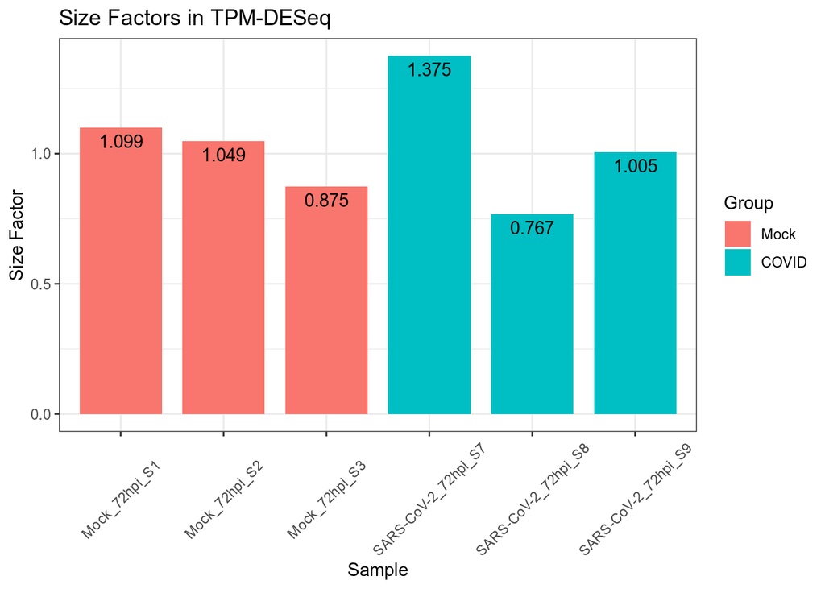

```r
# Extract and save the size factors in a data frame
sizeFactor <- as.data.frame(round(sizeFactors(TPM[[1]]), 3))

colnames(sizeFactor) <- 'Size_Factor'
sizeFactor <- sizeFactor %>%
    rownames_to_column(var="Sample") %>%
    inner_join(metadata[, 1:ncol(metadata)-1], by="Sample")

# Create a plot comparing the size factors by sample
ggplot(sizeFactor, aes(x=Sample,
                       y=Size_Factor,
                       fill=Group,
                       label=Size_Factor)) +
    geom_bar(stat="identity", width=0.8) +
    theme_bw() +
    ggtitle("Size Factors in TPM-DESeq") +
    geom_text(vjust=1.5) +
    theme(axis.text.x=element_text(angle=45,
                                   vjust=0.5)) + ylab("Size Factor")
```

## Plotting nornalization factors in the Counts

- DESeq2 performs an internal normalization where geometric mean is calculated for each gene across all samples. The counts for a gene in each sample is then divided by this mean. The median of these ratios in a sample is the size factor for that sample.
- Blue dashed line: normalization factor = 1

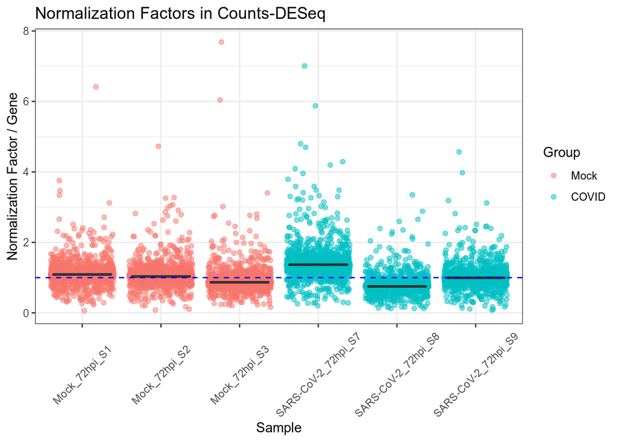

```r
# Extract and save normalization factors in a data frame
normf <- as.data.frame(normalizationFactors(Counts[[1]])) %>%
    gather(Sample, Normalization_Factor) %>%
    inner_join(metadata[, 1:2], by="Sample")

normf$Sample <- factor(normf$Sample, levels=SampleNames)
normf$Group <- factor(normf$Group, levels=GroupLevel)

# Create a scatter plot showing distribution of normalization factors
ggplot(normf,
       aes(x=Sample, y=Normalization_Factor)) +
geom_jitter(alpha=0.5, aes(color=Group)) +

# Add a boxplot to provide statistics in each sample
geom_boxplot(aes(x=Sample, y=Normalization_Factor),
             outlier.shape=NA) +
theme_bw() +
ggtitle("Normalization Factors in Counts-DESeq") +
theme(axis.text.x=element_text(angle=45,
                               vjust=0.5)) +
ylab("Normalization Factor / Gene") +

# Add a dashed horizontal line to indicate where normalization factor=1
geom_hline(yintercept=1,
           color="blue",
           linetype="dashed")
```

## Setting functions for QC plots

```r
# Assigne what to compare
GroupOfInterest <- Contrast[1]

# Set a function for a PCA plot
QCPCA_fn <- function(inputList, Title) {

    plotPCA(inputList[[2]],    # takes vsd
            intgroup=GroupOfInterest) + theme_bw() + ggtitle(Title)

}

# Set heatmap annotation
ColOfInterest <- !colnames(metadata) %in% c("Sample", "Path")
HeatmapAnno <- as.data.frame(metadata[, ColOfInterest])
rownames(HeatmapAnno) <- SampleNames
colnames(HeatmapAnno) <- colnames(metadata)[ColOfInterest]

# Set a function for a correlation heatmap
QCcorrHeatmap_fn <- function(inputList, Title) {

    # Extract transformed count matrix
    mtx <- assay(inputList[[2]])      # takes vsd

    # Calculate correlation and store in the matrix
    mtx <- cor(mtx)



    # Create a correlation heatmap
    return(pheatmap(mtx,
             annotation=HeatmapAnno,
             show_rownames=F,
             main=paste("Sample Correlation Heatmap:",
                        Title)))

}
```

## Sample QC: Principal Component Analysis

- Checkpoints in PCA: source of variation, sample outlier

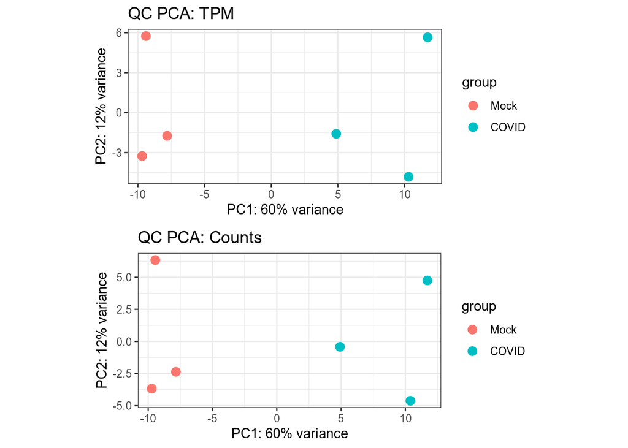

```r
grid.arrange(QCPCA_fn(TPM, "QC PCA: TPM"),
             QCPCA_fn(Counts, "QC PCA: Counts"),
             nrow=2)
```

## Sample QC: Sample Correlation Heatmap

- Checkpoint of correlation heatmap: distance between samples, correlation in a group

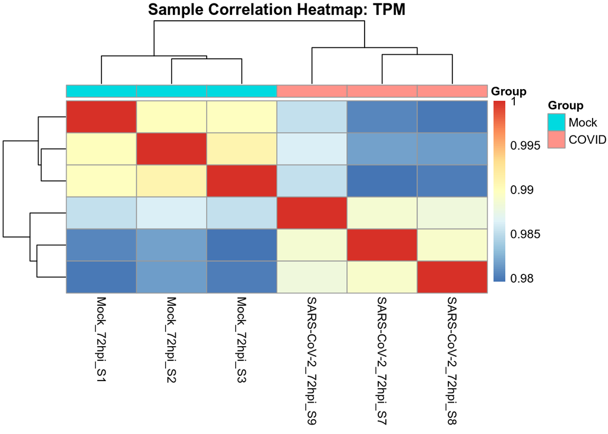

```r
# TPM
QCcorrHeatmap_fn(TPM, "TPM")
```

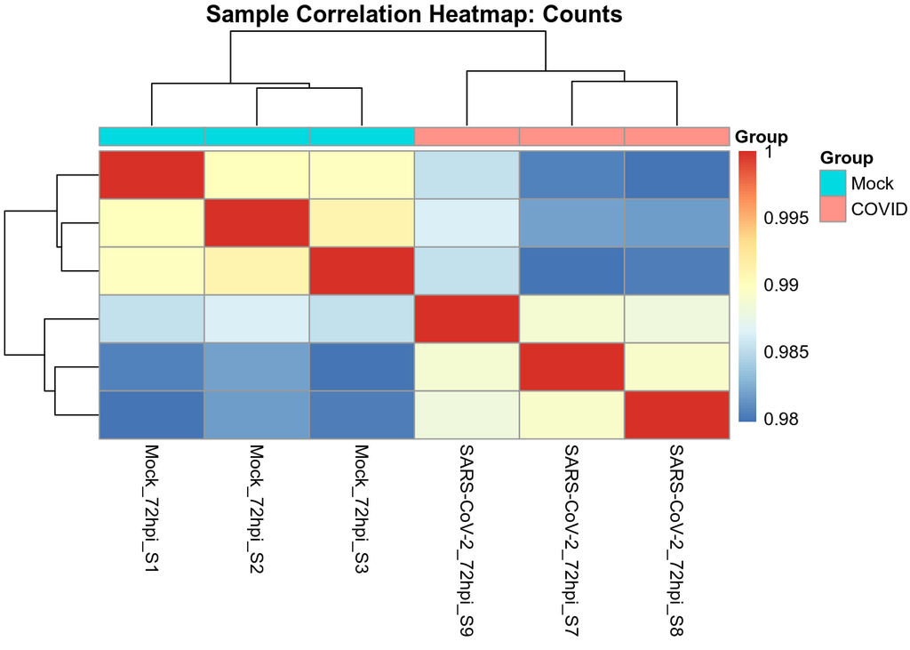

```r
# Counts
QCcorrHeatmap_fn(Counts, "Counts")
```

## Running DE analysis

```r
# Create a list for TPM and Counts dds
ddsList <- list(TPM=TPM[[1]], Counts=Counts[[1]])

for (x in TvC) {

    # Run DESeq()
    ddsList[[x]] <- DESeq(ddsList[[x]])
    print(resultsNames(ddsList[[x]]))
}
```

```
## [1] "Intercept"           "Group_COVID_vs_Mock"
## [1] "Intercept"           "Group_COVID_vs_Mock"
```

## Creating a dispersion plot

- Dispersion is important since estimation by DESeq2 algorithm is based on the assumption that genes with similar expression levels have similar dispersion. If an RNA-seq dataset doesn’t satisfy this assumption, use other DE algorithm than DESeq2.

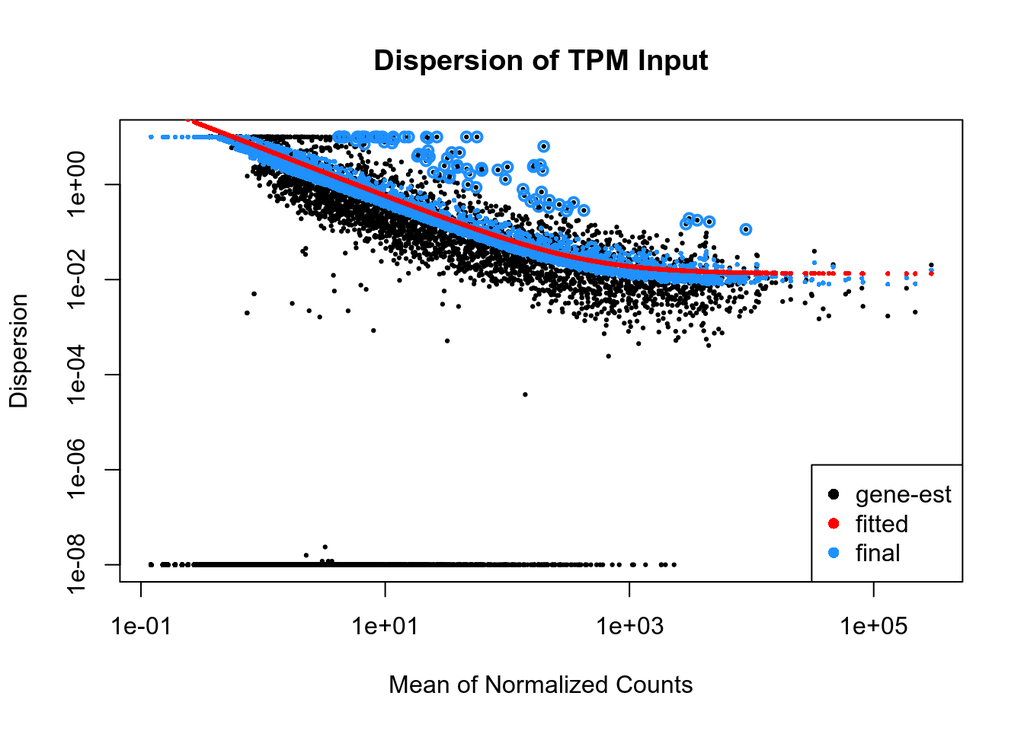

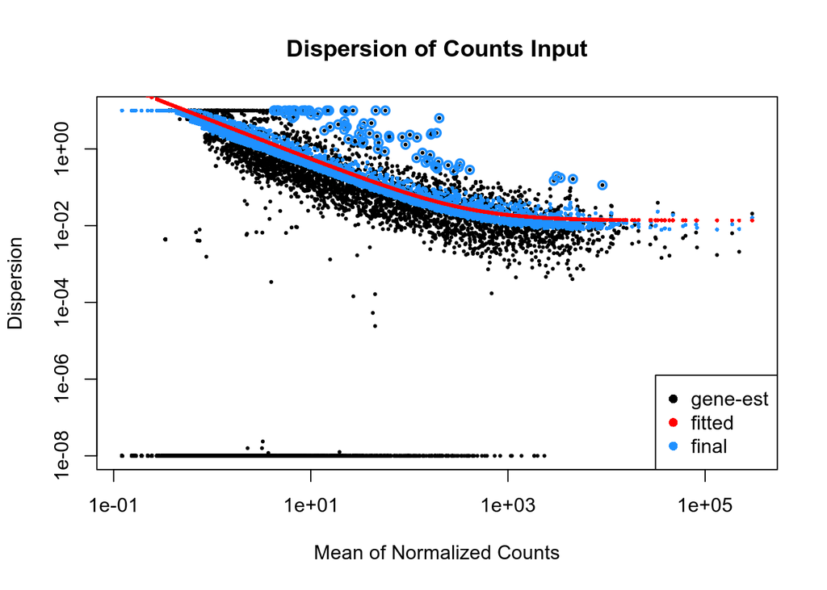

```r
# Plot dispersion

for (x in TvC) {

    plotDispEsts(ddsList[[x]],
                 ylab="Dispersion",
                 xlab="Mean of Normalized Counts",
                 main=paste("Dispersion of", x, "Input"))
}
```

## Performing shrinkage

- Shrinkage is beneficial to reduce false positives
- Magnitude of shrinkage is affected by dispersion and sample size
- When the **type** is set to **“apeglm”**, the **coef** argument is used instead of constrast. In this dataset, you can set **coef=Coef** where **Coef <- resultsNames(ddsList[[1]])**.
- When the **type** is set to **“normal”**, the **contrast** is set as shown below.

```r
# Create an empty list for shrunken dds
shr_ddsList <- list(TPM=c(), Counts=c())

for (x in TvC) {

    # shrink
    shr_ddsList[[x]] <- lfcShrink(ddsList[[x]],
                                  contrast=Contrast, # contrast
                                  type="normal")     # is paired with "normal" type
}
```

# Extracting log2FoldChange and p-values with or without shrinkage

- The **alpha** denotes threshold of **false discovery rate (FDR)** assigned by users.
- In this analysis, alpha is set to 0.1

```r
# Set FDR threshold
alpha=0.1

# Set a function cleaning table
Sig_fn <- function(df, Input) {

    df <- df %>%
        rownames_to_column(var="Gene") %>%
        mutate(FDR=ifelse(padj < 0.1 & !is.na(padj),
                                   "< 0.1",
                                   "> 0.1"),
               Input=Input)

    return(df)
}


# Initialize lists of result tables with (resList) or without (shr_resList) shrinkage
resList <- ddsList

shr_resList <- ddsList

for (x in TvC) {

    # Extract results
    resList[[x]] <- as.data.frame(results(ddsList[[x]],
                                          contrast=Contrast,
                                          alpha=alpha))

    shr_resList[[x]] <- as.data.frame(shr_ddsList[[x]])

    # clean the data frame
    resList[[x]] <- Sig_fn(resList[[x]], x)
    shr_resList[[x]] <- Sig_fn(shr_resList[[x]], x)

}
```

## Exploratory data analysis of the extracted log2FoldChange tables

```r
# No shrinkage summary
summary(resList)
```

```
##        Length Class      Mode
## TPM    9      data.frame list
## Counts 9      data.frame list
```

```r
head(resList[['TPM']])
```

```
##      Gene   baseMean log2FoldChange     lfcSE        stat    pvalue      padj
## 1   A2MP1  3.2145217    -0.83018949 1.7557571 -0.47283846 0.6363284        NA
## 2 A3GALT2  0.0000000             NA        NA          NA        NA        NA
## 3   A4GNT  0.8330031    -1.92416012 3.0773846 -0.62525826 0.5318016        NA
## 4  AACSP1 14.5467370     0.02184858 0.7549595  0.02894006 0.9769124 0.9923554
## 5 AADACL2  0.0000000             NA        NA          NA        NA        NA
## 6 AADACL4  0.9670271    -0.35981582 2.9306060 -0.12277864 0.9022824        NA
##     FDR Input
## 1 > 0.1   TPM
## 2 > 0.1   TPM
## 3 > 0.1   TPM
## 4 > 0.1   TPM
## 5 > 0.1   TPM
## 6 > 0.1   TPM
```

```r
head(resList[['Counts']])
```

```
##      Gene   baseMean log2FoldChange    lfcSE        stat    pvalue      padj
## 1   A2MP1  2.9604793    -0.90913229 1.813261 -0.50137976 0.6161039        NA
## 2 A3GALT2  0.0000000             NA       NA          NA        NA        NA
## 3   A4GNT  0.8386688    -1.90512920 3.007858 -0.63338401 0.5264829        NA
## 4  AACSP1 14.0360149    -0.06225852 0.760773 -0.08183586 0.9347772 0.9796733
## 5 AADACL2  0.0000000             NA       NA          NA        NA        NA
## 6 AADACL4  0.9793046    -0.35701152 2.864781 -0.12462089 0.9008237        NA
##     FDR  Input
## 1 > 0.1 Counts
## 2 > 0.1 Counts
## 3 > 0.1 Counts
## 4 > 0.1 Counts
## 5 > 0.1 Counts
## 6 > 0.1 Counts
```

```r
# Shrinkage summary
summary(shr_resList)
```

```
##        Length Class      Mode
## TPM    9      data.frame list
## Counts 9      data.frame list
```

```r
head(shr_resList[['TPM']])
```

```
##      Gene   baseMean log2FoldChange     lfcSE        stat    pvalue      padj
## 1   A2MP1  3.2145217     -0.1588907 0.3391943 -0.47283846 0.6363284        NA
## 2 A3GALT2  0.0000000             NA        NA          NA        NA        NA
## 3   A4GNT  0.8330031     -0.1303038 0.2238159 -0.62525826 0.5318016        NA
## 4  AACSP1 14.5467370      0.0122880 0.4253130  0.02894006 0.9769124 0.9923554
## 5 AADACL2  0.0000000             NA        NA          NA        NA        NA
## 6 AADACL4  0.9670271     -0.0275875 0.2314025 -0.12277864 0.9022824        NA
##     FDR Input
## 1 > 0.1   TPM
## 2 > 0.1   TPM
## 3 > 0.1   TPM
## 4 > 0.1   TPM
## 5 > 0.1   TPM
## 6 > 0.1   TPM
```

```r
head(shr_resList[['Counts']])
```

```
##      Gene   baseMean log2FoldChange     lfcSE        stat    pvalue      padj
## 1   A2MP1  2.9604793    -0.15661253 0.3347863 -0.50137976 0.6161039        NA
## 2 A3GALT2  0.0000000             NA        NA          NA        NA        NA
## 3   A4GNT  0.8386688    -0.13471856 0.2283621 -0.63338401 0.5264829        NA
## 4  AACSP1 14.0360149    -0.03454845 0.4258173 -0.08183586 0.9347772 0.9796733
## 5 AADACL2  0.0000000             NA        NA          NA        NA        NA
## 6 AADACL4  0.9793046    -0.02852632 0.2359889 -0.12462089 0.9008237        NA
##     FDR  Input
## 1 > 0.1 Counts
## 2 > 0.1 Counts
## 3 > 0.1 Counts
## 4 > 0.1 Counts
## 5 > 0.1 Counts
## 6 > 0.1 Counts
```

## Exploring mean-difference relationship with MA plots

- Red dashed lines: log2FoldChange = -1 and 1

```r
# Set ylim: has to adjusted by users depending on data
yl <- c(-20, 20)

# Set min log2 fold change of interest
mLog <- c(-1, 1)

# Define a function creating an MA plot
MA_fn <- function(List, Shr) {

    MAList <- ddsList

    for (i in 1:2) {

        MAplot <- ggplot(List[[i]],
                         aes(x=baseMean,
                             y=log2FoldChange,
                             color=FDR)) + geom_point() + scale_x_log10() + theme_bw() + scale_color_manual(values=c("blue", "grey")) + ggtitle(paste("MA plot:", names(List)[i], "Input with", Shr)) + ylim(yl[1], yl[2])+ geom_hline(yintercept=c(mLog[1], mLog[2]), linetype="dashed", color="red")

        MAList[[i]] <- MAplot

    }

    return(MAList)

}


# Create MA plots with or without shrinkage and store in a list
MA <- MA_fn(resList, "No Shrinkage")
shr_MA <- MA_fn(shr_resList, "Shrinkage")
```

## Visualizing MA plots

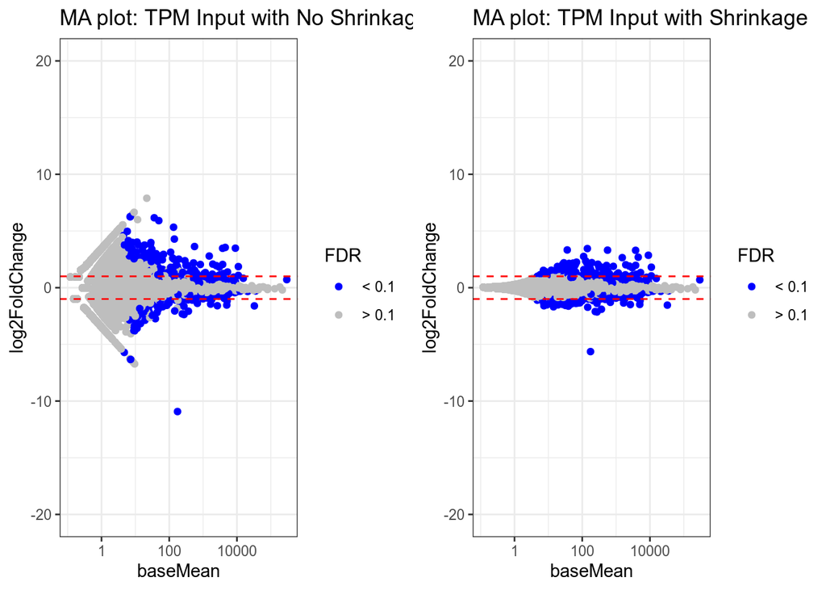

```r
# TPM with or without shrinkage
grid.arrange(MA[[1]], shr_MA[[1]], nrow=1)
```

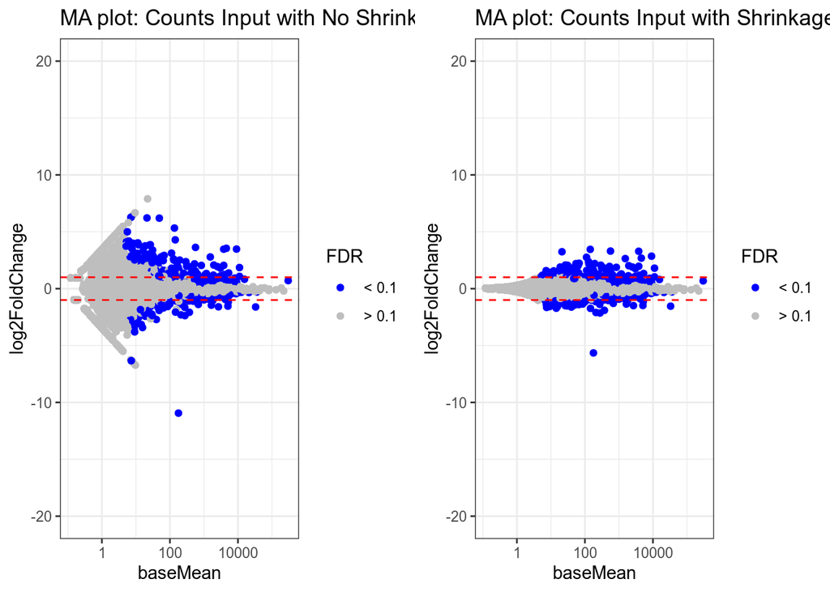

```r
# TPM with or without shrinkage
grid.arrange(MA[[2]], shr_MA[[2]], nrow=1)
```

## Exploring distribution of false discovery rate (FDR)

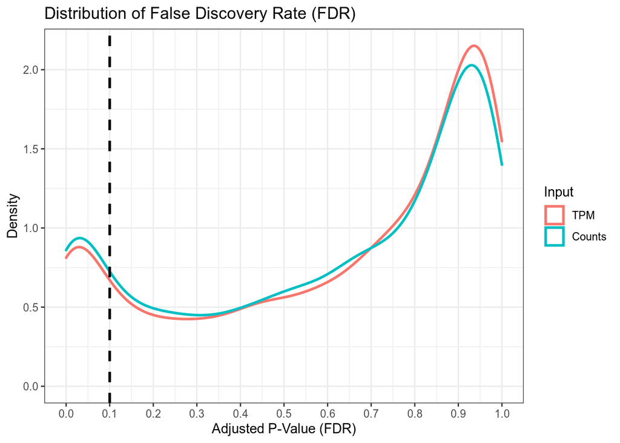

```r
# Combining total data table
res <- rbind(shr_resList[['TPM']], shr_resList[['Counts']])
res$Input <- factor(res$Input, levels=TvC)  # TvC=c("TPM", "Counts")

# Create a plot presenting distribution of FDR
ggplot(res,
       aes(x=padj, color=Input)) +
geom_density(size=1) +
theme_bw() +
ggtitle("Distribution of False Discovery Rate (FDR)") +
xlab("Adjusted P-Value (FDR)") +
ylab("Density") +
geom_vline(xintercept=alpha,
           color="black",
           linetype="dashed",
           size=1) +
scale_x_continuous(breaks=seq(0, 1, by=0.1))
```

## Volcano plots

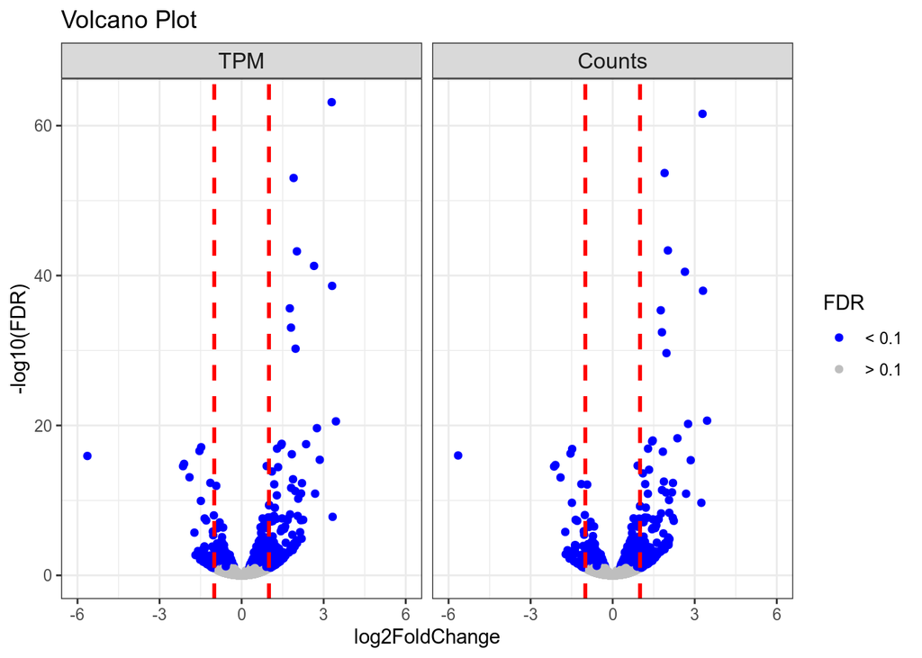

```r
# Set xlim for volcano plots
xlim=c(-6, 6)    # has to be assined by users

# Set a basic volcano plot function
Volcano_fn <- function(df, Label=NULL) {


ggplot(res,
       aes(x=log2FoldChange,
           y= -log10(padj),
           color=FDR,
           label=Label)) +
geom_point() +
facet_grid(.~Input) +
theme_bw() +
scale_color_manual(values=c("blue", "grey")) +
ggtitle("Volcano Plot") +
ylab("-log10(FDR)") +
theme(strip.text.x=element_text(size=12)) +
geom_vline(xintercept=c(mLog[1], mLog[2]),
           color="red",
           linetype="dashed",
           size=1) +
xlim(xlim[1], xlim[2])
}

# Display the volcano plots by input
Volcano_fn(res)
```

## Volcano plots with promising genes

- **Log odds** threshold (y-axis): **> 20**

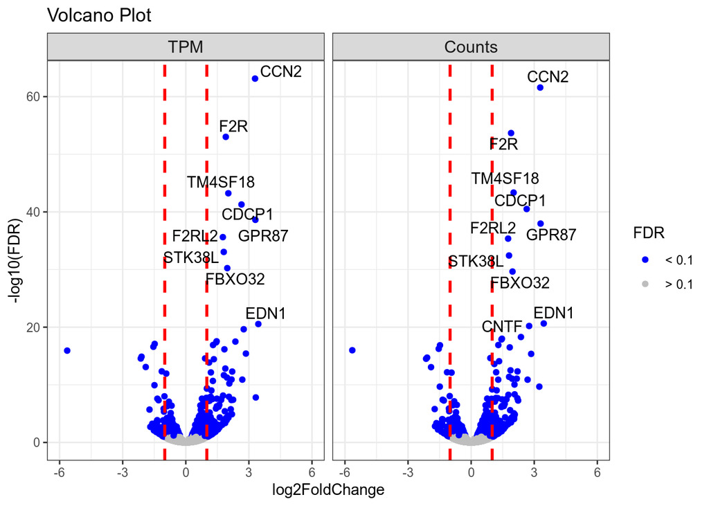

```r
# Assign log odds threshold
LogOddsCut=20


# Add a column indicating high log odds genes
res <- res %>%
    mutate(Label=ifelse(-log10(padj) > LogOddsCut,
                                   Gene,
                                   ""))

# Display the genes with volcano plots
Volcano_fn(res, Label=res$Label) + geom_text_repel(color="black")
```

## Exploring distribution of log2FoldChange by input type

- Black dashed lines: log2FoldChange = -1 and 1

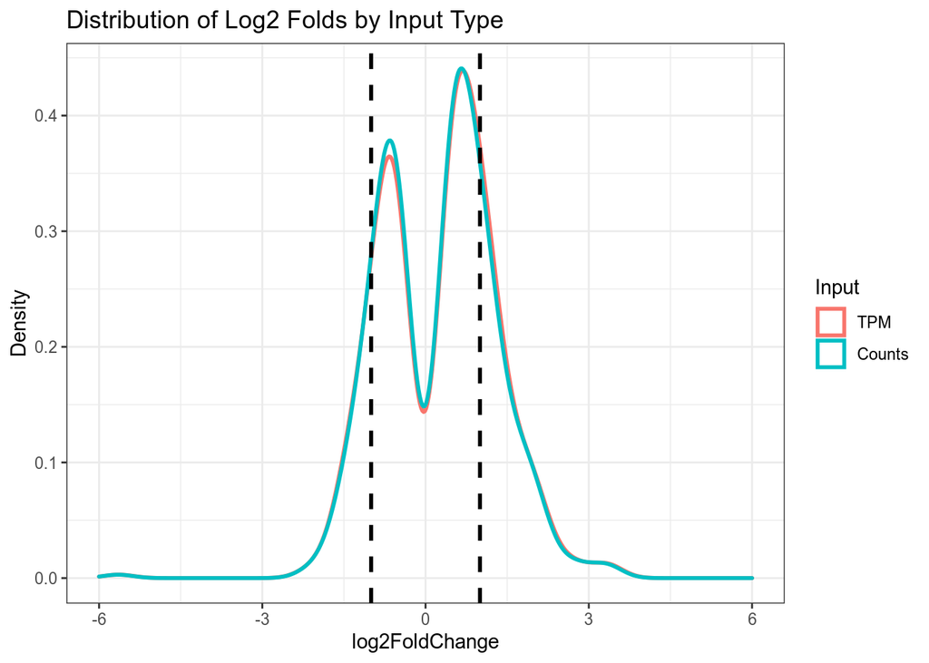

```r
ggplot(res[res$FDR == "< 0.1", ],  # Subset rows with FDR < alpha
       aes(x=log2FoldChange,
           color=Input)) +
geom_density(size=1) +
theme_bw() +
ylab("Density") +
geom_vline(xintercept=c(mLog[1], mLog[2]),
           color="black",
           linetype="dashed", size=1) +
ggtitle("Distribution of Log2 Folds by Input Type") +
xlim(xlim[1], xlim[2])
```

## Exploring expression profiling

- Normalized count matrices are extracted from dds objects and cleaned with thresholds set at FDR and log2FoldChange
- The heatmaps display z-scores instead of the normalized counts
- **lowfdrList**: a list of matrices filtered with **FDR < alpha**
- **highfoldList**: a list of matrices filtered with **FDR < alpha** AND **absolute log2FoldChange > user’s minimum threshold (mLog)**
- In this analysis, mLog was set to 1

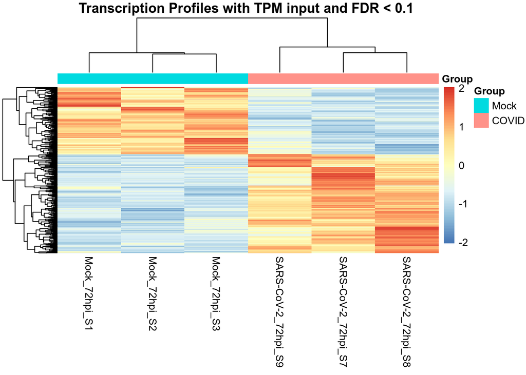

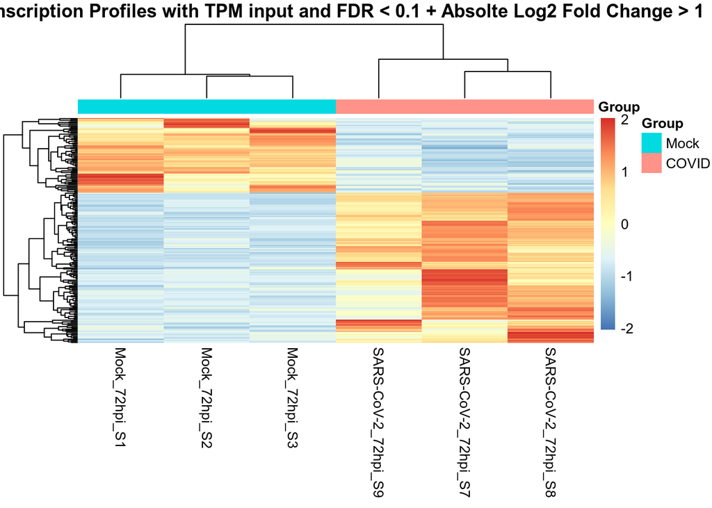

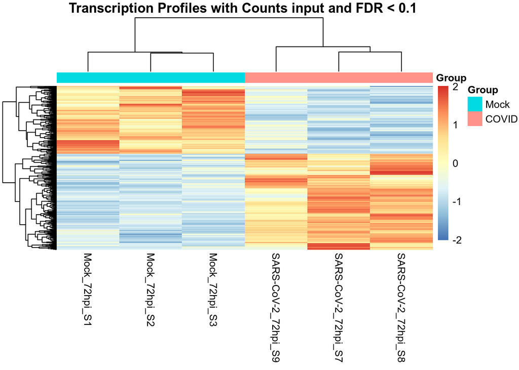

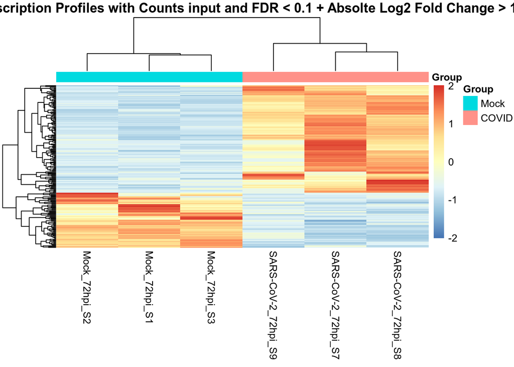

```r
# Initialize a list
lowfdrList <- ddsList   # A list for normalized counts matrix with FDR below alpha
highfoldList <- ddsList  # A list for normalized counts with log2foldchange over minLog



for (x in TvC) {

    # Create filtering vectors with alpha and log2foldchange
    BelowAlpha <- resList[[x]]$FDR == "< 0.1"
    overmLog <- abs(resList[[x]]$log2FoldChange) > mLog[2]  # mLog has been set to c(-1, 1) previously

    # Extract transformed counts from vsd objects (TPM[['vsd']] and Counts[['vsd']])
    if (x == "TPM") {

        normCounts <- counts(TPM[['dds']], normalized=T)

    } else {

        normCounts <- counts(Counts[['dds']], normalized=T)
    }


    # Update the normalized count matrix with FDR below alpha
    lowfdrList[[x]] <- normCounts[BelowAlpha, ]
    highfoldList[[x]] <- normCounts[BelowAlpha & overmLog, ]

    summary(lowfdrList[[x]])
    summary(highfoldList[[x]])
}

# Initialize map lists
lowfdrMap <- ddsList
highfoldMap <- ddsList

# Set a function creating a heatmap
ProfileHeatmap_fn <- function(inputmatrix, Title1, Title2, Title3=NULL) {

    as.ggplot(pheatmap(inputmatrix,
             annotation=HeatmapAnno,
             scale="row",         # presents z-score instead of counts
             show_rownames=F,
             main=paste("Transcription Profiles with",
                        Title1,
                        "input and",
                        Title2,
                        alpha,
                        Title3)))
}

# Create and save heatmaps
for (x in TvC) {

    lowfdrMap[[x]] <- ProfileHeatmap_fn(lowfdrList[[x]],
                                        Title1=x,
                                        Title2="FDR <")

    highfoldMap[[x]] <- ProfileHeatmap_fn(highfoldList[[x]],
                                          Title1=x,
                                          Title2="FDR <",
                                          Title3=paste("+ Absolte Log2 Fold Change >", mLog[2]))
}
```

## NA statistics: zero count genes & outlier genes

### When NAs appear in

- **log2FoldChange**: zero counts in all samples
- **padj**: too little information
- **pval & padj**: at least one replicate was an outlier

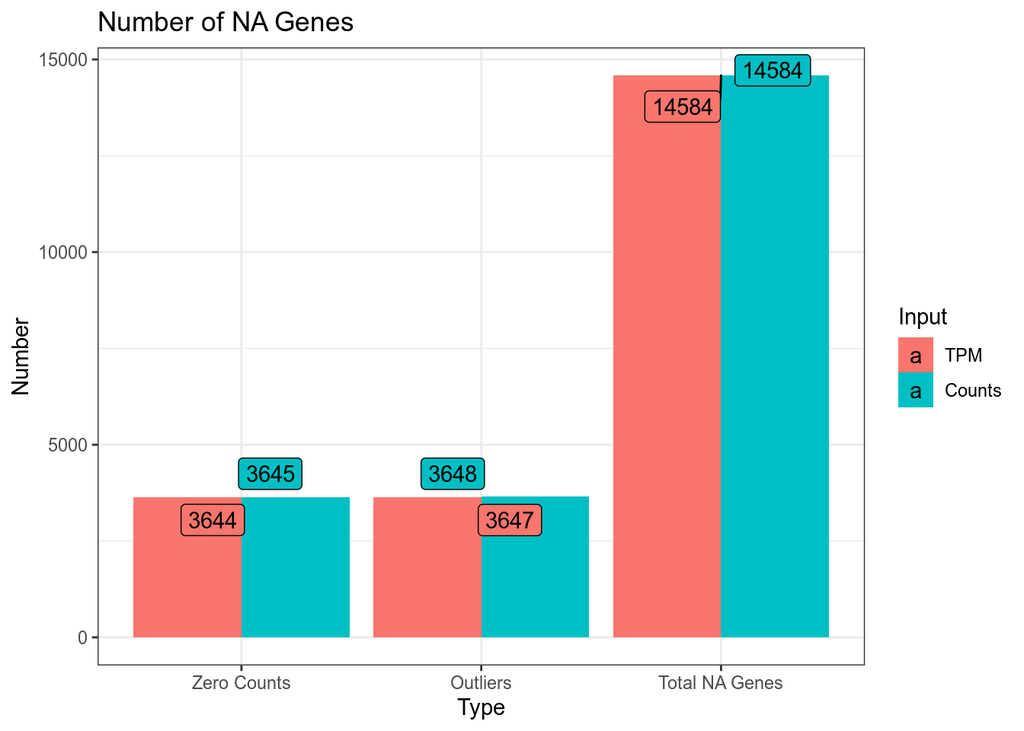

```r
type=c("Zero Counts", "Outliers", "Total NA Genes")

NAstat <- res %>%
    group_by(Input) %>%
    summarize(zero=sum(is.na(log2FoldChange)),
              outlier=sum(is.na(pvalue) & is.na(padj))) %>%
    mutate(total=sum(zero, outlier)) %>%
    gather(Type, Number, -Input) %>%
    mutate(Type=factor(case_when(Type == "zero" ~ type[1],
                                 Type == "outlier" ~ type[2],
                                 Type == "total" ~ type[3]),
                       levels=type))



ggplot(NAstat, aes(x=Type, y=Number, group=Input, fill=Input, label=Number)) +
    geom_bar(stat="identity", position="dodge") +
    theme_bw() +
    geom_label_repel() +
    ggtitle("Number of NA Genes")
```